# Exercici 1

Resumeix gràficament el data set DelayedFlights.csv

Crea almenys una visualització per:

```
Una variable categòrica (UniqueCarrier)
Una variable numèrica (ArrDelay)
Una variable numèrica i una categòrica (ArrDelay i UniqueCarrier)
Dues variables numèriques (ArrDelay i DepDelay)
Tres variables (ArrDelay, DepDelay i UniqueCarrier)
Més de tres variables (ArrDelay, DepDelay, AirTime i UniqueCarrier).
```

We are working with de Dataframe about flyes for 2008 and it has the next variables:

- YEAR — Year in which flight took place
- QUARTER — Quarter in which flight took place (1–4)
- MONTH — Month in which flight took place (1–12)
- DAY_OF_MONTH — Day of the month in which flight took place (1–31)
- DAY_OF_WEEK — 1 for Monday, 2 for Tuesday,etc. in which flight took place
- UNIQUE_CARRIER — Airline carrier code
- TAIL_NUM — Aircraft tail number
- FL_NUM — Flight number
- ORIGIN_AIRPORT_ID — ID of origin airport
- ORIGIN — Code of origin airport(ATL, DFW, SEA, etc.)
- DEST_AIRPORT_ID — ID of destination airport
- DEST — Code of destination airport (ATL, DFW, SEA, etc.)
- CRS_DEP_TIME — Scheduled departure time
- DEP_TIME — Actual departure time
- DEP_DELAY — Departure Delay in minutes
- DEP_DEL15 — 1 if departure is delayed by 15 minutes or more else 0
- CRS_ARR_TIME — Scheduled arrival time
- ARR_TIME — Actual arrival time
- ARR_DELAY — Arrival Delay in minutes
- ARR_DEL15 — 1 if arrived late by 15 minutes or more else 0
- CANCELLED — 1 if Flight was cancelled else 0
- DIVERTED — 1 if Flight was diverted else 0
- CRS_ELAPSED_TIME — Scheduled flight time in minutes
- ACTUAL_ELAPSED_TIME — Actual flight time in minutes
- DISTANCE — Distance traveled in miles

```python
import numpy as np
import pandas as pd
import matplotlib.pyplot as plt
import seaborn as sns
```

```python
#Load flyes
fly = pd.read_csv("C:/Users/Guillermo/Desktop/Curs Data Scientist/Sprint 2/S02 T05 Exploració de les dades/DelayedFlights.csv")
```

```python
fly.columns
```

```
Index(['Unnamed: 0', 'Year', 'Month', 'DayofMonth', 'DayOfWeek', 'DepTime',
       'CRSDepTime', 'ArrTime', 'CRSArrTime', 'UniqueCarrier', 'FlightNum',
       'TailNum', 'ActualElapsedTime', 'CRSElapsedTime', 'AirTime', 'ArrDelay',
       'DepDelay', 'Origin', 'Dest', 'Distance', 'TaxiIn', 'TaxiOut',
       'Cancelled', 'CancellationCode', 'Diverted', 'CarrierDelay',
       'WeatherDelay', 'NASDelay', 'SecurityDelay', 'LateAircraftDelay'],
      dtype='object')
```

```python
fly = fly.drop(['Unnamed: 0','Year'], axis = 1)
```

```python
fly.columns
```

```
Index(['Month', 'DayofMonth', 'DayOfWeek', 'DepTime', 'CRSDepTime', 'ArrTime',
       'CRSArrTime', 'UniqueCarrier', 'FlightNum', 'TailNum',
       'ActualElapsedTime', 'CRSElapsedTime', 'AirTime', 'ArrDelay',
       'DepDelay', 'Origin', 'Dest', 'Distance', 'TaxiIn', 'TaxiOut',
       'Cancelled', 'CancellationCode', 'Diverted', 'CarrierDelay',
       'WeatherDelay', 'NASDelay', 'SecurityDelay', 'LateAircraftDelay'],
      dtype='object')
```

One plot for UniqueCarrier

```python
fly.info()
```

```
<class 'pandas.core.frame.DataFrame'>
RangeIndex: 1936758 entries, 0 to 1936757
Data columns (total 28 columns):
 #   Column             Dtype
---  ------             -----
 0   Month              int64
 1   DayofMonth         int64
 2   DayOfWeek          int64
 3   DepTime            float64
 4   CRSDepTime         int64
 5   ArrTime            float64
 6   CRSArrTime         int64
 7   UniqueCarrier      object
 8   FlightNum          int64
 9   TailNum            object
```

[output cut: 20 more lines]

```python
fly.nunique()
```

```
Month                  12
DayofMonth             31
DayOfWeek               7
DepTime              1438
CRSDepTime           1207
ArrTime              1440
CRSArrTime           1364
UniqueCarrier          20
FlightNum            7499
TailNum              5366
ActualElapsedTime     673
CRSElapsedTime        515
AirTime               650
ArrDelay             1128
DepDelay             1058
Origin                303
Dest                  304
Distance             1419
TaxiIn                180
TaxiOut               332
Cancelled               2
CancellationCode        4
Diverted                2
CarrierDelay          983
WeatherDelay          599
NASDelay              574
SecurityDelay         156
LateAircraftDelay     564
dtype: int64
```

**Una variable categòrica (UniqueCarrier)** -->Unique carrier is a variable with 20 possible values. So, one option is to explore how many times appears every airline carrier code. We can do two different aproximations. First, with a bars a plot, and second, with a pie chart.

```python
fly.columns
```

```
Index(['Month', 'DayofMonth', 'DayOfWeek', 'DepTime', 'CRSDepTime', 'ArrTime',
       'CRSArrTime', 'UniqueCarrier', 'FlightNum', 'TailNum',
       'ActualElapsedTime', 'CRSElapsedTime', 'AirTime', 'ArrDelay',
       'DepDelay', 'Origin', 'Dest', 'Distance', 'TaxiIn', 'TaxiOut',
       'Cancelled', 'CancellationCode', 'Diverted', 'CarrierDelay',
       'WeatherDelay', 'NASDelay', 'SecurityDelay', 'LateAircraftDelay'],
      dtype='object')
```

```python
#np.sum(fly['UniqueCarrier']) No funciona para obtener valores absolutos de cada caso
```

```python
table_airlines = fly['UniqueCarrier'].value_counts()
```

```python
print(table_airlines)
```

```
WN    377602
AA    191865
MQ    141920
UA    141426
OO    132433
DL    114238
XE    103663
CO    100195
US     98425
EV     81877
NW     79108
FL     71284
YV     67063
B6     55315
OH     52657
9E     51885
AS     39293
F9     28269
HA      7490
AQ       750
Name: UniqueCarrier, dtype: int64
```

```python
print(table_airlines.shape)
print(table_airlines.ndim)
print(table_airlines[3])
```

```
(20,)
1
141426
```

```python
airline_names = fly['UniqueCarrier'].unique()
print(airline_names)
```

```
['WN' 'XE' 'YV' 'OH' 'OO' 'UA' 'US' 'DL' 'EV' 'F9' 'FL' 'HA' 'MQ' 'NW'
 '9E' 'AA' 'AQ' 'AS' 'B6' 'CO']
```

[figure not shown]

```python
#with matplotlib

#Bar plot
plt.subplot(1,2,1)
plt.bar(x= airline_names, height = table_airlines)

#Pie plot
plt.subplot(1,2,2)
plt.pie(table_airlines, labels = airline_names)

plt.suptitle("Airlines absolut frecuency")
plt.show()
```

```python
import squarify
```

```python
#with sns
sns.set() #set seaborn plotting aesthetics as default
```

[figure not shown]

```python
#Subplots
fig, axes = plt.subplots(1, 2, figsize=(16, 8))

#bars
plt.subplot(1,2,1)
bars_airlines = sns.barplot(x = airline_names, y = table_airlines, palette = 'deep')
bars_airlines.set(xlabel='Airlines', ylabel='Absolut frecuency')



#treeplot
plt.subplot(1,2,2)
squarify.plot(sizes = table_airlines, label = airline_names, alpha=.8)
plt.axis('off')

plt.show()
```

**Una variable numèrica (ArrDelay)** --> ArrDealy is the Arrival Delay in minutes. One option is plot the information in an histogram.

```python
import math
```

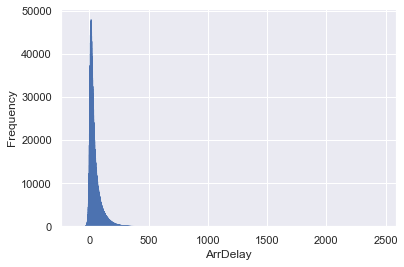

```python
#fly['ArrDelayFloat'] = float(fly['ArrDelay'])
#fig, axes = plt.subplots(1, 1, figsize=(16, 8))
sns.set()
sns.histplot(fly['ArrDelay'] , stat = 'frequency', element = "step")
plt.show()
```

**Una variable numèrica i una categòrica (ArrDelay i UniqueCarrier)**

Now, the next plot will have to associate a numerical variable (ArrDelay) with a categorical variable (UniqueCarrier). As we have a bigger number of airlines (20), we will need a plot, wich can summyrize all the delays by airlines.

On the other hand, our sample is too bigger for the next plots, therefore, it will be subsampled. The total rows are 1936758 and we will work a representative sample of 20%, which corresponds to 387352 and another with the 5% of the sample with 96838 rows.

```python
subsample = fly.sample(frac = 0.2)
subsample2=fly.sample(frac=0.05)
subsample.head()
```

|  | Month | DayofMonth | DayOfWeek | DepTime | CRSDepTime | ArrTime | CRSArrTime | UniqueCarrier | FlightNum | TailNum | ... | TaxiIn | TaxiOut | Cancelled | CancellationCode | Diverted | CarrierDelay | WeatherDelay | NASDelay | SecurityDelay | LateAircraftDelay |
| --- | --- | --- | --- | --- | --- | --- | --- | --- | --- | --- | --- | --- | --- | --- | --- | --- | --- | --- | --- | --- | --- |
| 1129741 | 7 | 27 | 7 | 1550.0 | 1515 | 1550.0 | 1515 | OH | 5731 | N518CA | ... | 4.0 | 24.0 | 0 | N | 0 | 0.0 | 0.0 | 0.0 | 0.0 | 35.0 |
| 1223273 | 7 | 25 | 5 | 1528.0 | 1520 | 1838.0 | 1835 | AA | 360 | N533AA | ... | 8.0 | 11.0 | 0 | N | 0 | NaN | NaN | NaN | NaN | NaN |
| 1115496 | 7 | 15 | 2 | 2115.0 | 2045 | 9.0 | 2352 | XE | 2820 | N16918 | ... | 6.0 | 14.0 | 0 | N | 0 | 17.0 | 0.0 | 0.0 | 0.0 | 0.0 |
| 759577 | 5 | 12 | 1 | 1447.0 | 1400 | 1720.0 | 1654 | XE | 319 | N11192 | ... | 4.0 | 8.0 | 0 | N | 0 | 6.0 | 0.0 | 0.0 | 0.0 | 20.0 |
| 82807 | 1 | 3 | 4 | 2034.0 | 1850 | 2250.0 | 2154 | US | 1619 | N932UW | ... | 3.0 | 9.0 | 0 | N | 0 | 0.0 | 0.0 | 0.0 | 0.0 | 56.0 |

5 rows × 28 columns

```python
print(subsample.shape)
print(subsample2.shape)
```

```
(387352, 28)
(96838, 28)
```

```python
subsample2["ArrDelay"].min()
```

```
-68.0
```

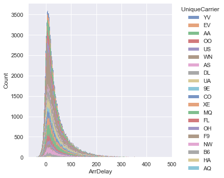

```python
sns.set()

#sns.lmplot(x="ArrDelay", data= subsample2, fit_reg=False )

sns.displot(data=subsample2, x="ArrDelay", hue="UniqueCarrier", multiple="stack" ,palette='deep')

plt.xlim(-70,500)

plt.show()
```

The above plot shows the most frequent delay. The x axe has been cut in 500 to facilitate the plot vision.

The next plots show the same information throught other techniques.

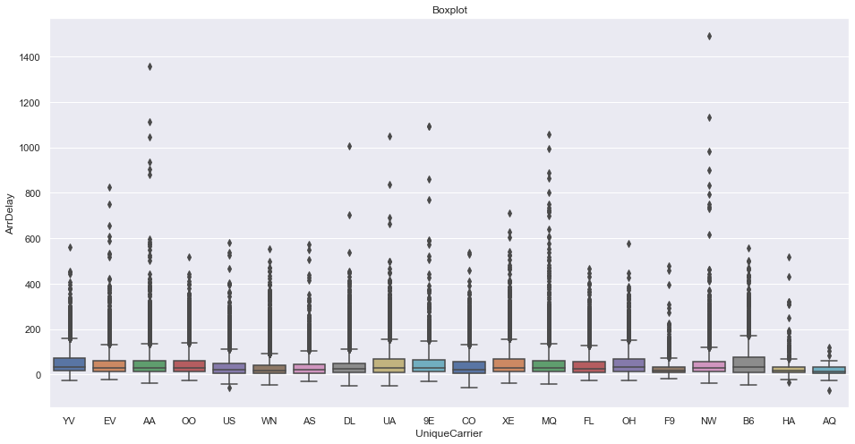

```python
#boxplot
#plt.subplot(2,2,1)
sns.boxplot(data=subsample2, x='UniqueCarrier', y='ArrDelay', palette = 'deep')
plt.title('Boxplot')
plt.show()
```

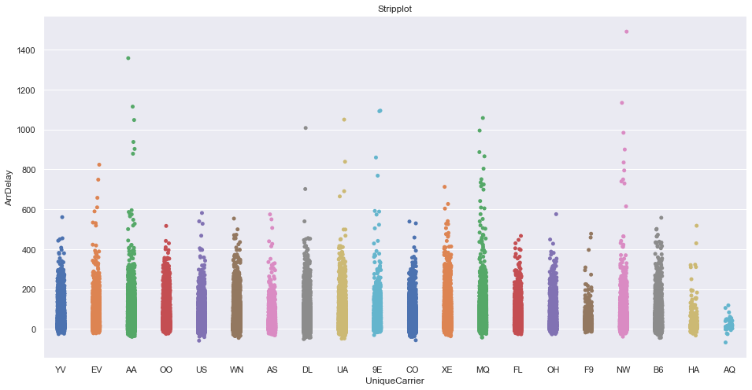

```python
#stripplot
#plt.subplot(2,2,2)
sns.stripplot(data=subsample2, x='UniqueCarrier', y='ArrDelay', palette ='deep')
plt.title('Stripplot')
plt.show()
```

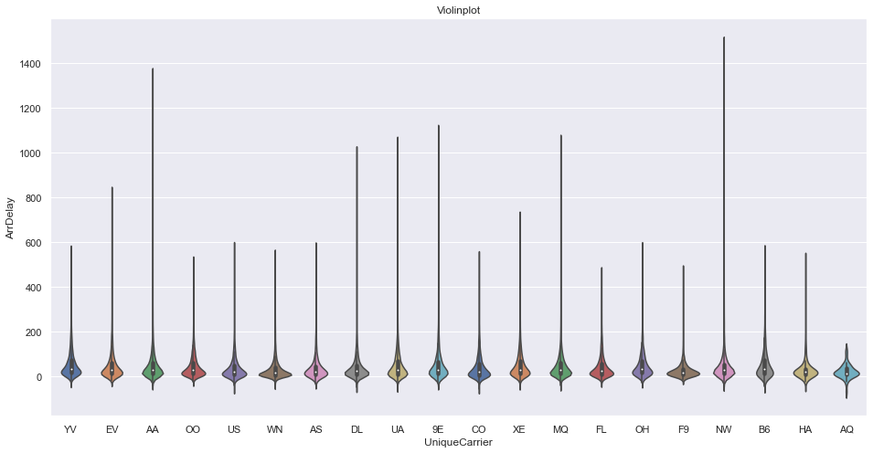

```python
#violinplot
#plt.subplot(2,2,3)
sns.violinplot(data=subsample2, x='UniqueCarrier', y='ArrDelay', palette = 'deep')
plt.title('Violinplot')
plt.show()
```

[output not shown]

[output not shown]

[output cut: 49 more lines]

[output not shown]

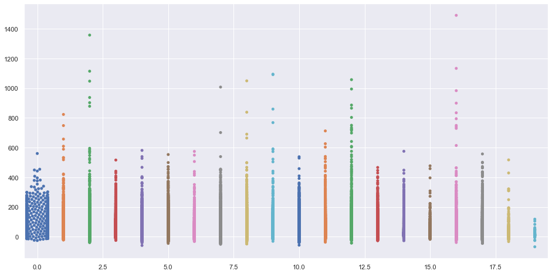

```python
#swarmplot
#plt.subplot(2,2,4)
sns.swarmplot(data=subsample2, x='UniqueCarrier', y='ArrDelay', palette = 'deep')
plt.title('swarmplot')
plt.show()
```

```python
#The sample is too bigger yet. So it will be been smaller.
subsample3 = fly.sample(n=15000)
subsample3.shape
```

```
(15000, 28)
```

[output not shown]

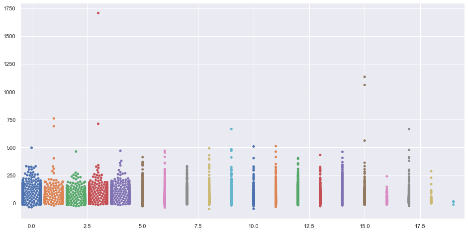

```python
#swarmplot smaller
#plt.subplot(2,2,4)
sns.swarmplot(data=subsample3, x='UniqueCarrier', y='ArrDelay', palette = 'deep')
plt.title('swarmplot')
plt.show()
```

In the boxplot, all airlines show a lot of outliers beyond the upper limit. This is normal because we are working with the delays. Also, the mostly boxplots are asymmetric, where are more flies upper the median.

The scatterplot, as the boxplot, it shows the outliers, but facilitate to identify the airlines with more outliers.

The violinplot shows a mixture between boxplot and histogram. As the previous plots show the outliers but it doesn’t inform about how many. On the other hand, WN and FN show the delay centered in a determinate delay.

```python
#Don't do it because it needs to time of processing

#Subplots
fig, axes = plt.subplots(2, 2, figsize=(16, 8))

#boxplot
plt.subplot(2,2,1)
sns.boxplot(data=subsample2, x='UniqueCarrier', y='ArrDelay', palette = 'deep')
plt.title('Boxplot')

#stripplot
plt.subplot(2,2,2)
sns.stripplot(data=subsample2, x='UniqueCarrier', y='ArrDelay', palette ='deep')
plt.title('Stripplot')

#violinplot
plt.subplot(2,2,3)
sns.violinplot(data=subsample2, x='UniqueCarrier', y='ArrDelay', palette = 'deep')
plt.title('Violinplot')

#swarmplot
plt.subplot(2,2,4)
sns.swarmplot(data=subsample2, x='UniqueCarrier', y='ArrDelay', palette = 'deep')
plt.title('swarmplot')

plt.show()
```

[output not shown]

[output not shown]

[output not shown]

[output cut: 130 more lines]

[output not shown]

**Dues variables numèriques (ArrDelay i DepDelay)**

Plot with two numerical variables

```python
print(subsample2['DepDelay'].describe())
print(subsample2['ArrDelay'].describe())
```

[output not shown]

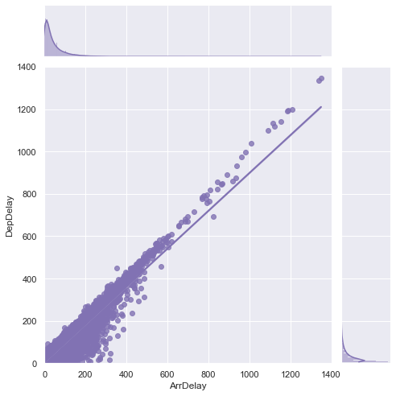

```python
sns.jointplot(data=subsample2, x='ArrDelay', y='DepDelay',
             xlim=(0, 1400), ylim=(0, 1400), kind='reg',
            color="m", height=7)

plt.show()
```

As expected, the delays in departures have a direct correlation with the arrival delays. Moreover, most delays are in the first few minutes like show the histograms.

**Tres variables (ArrDelay, DepDelay i UniqueCarrier)**

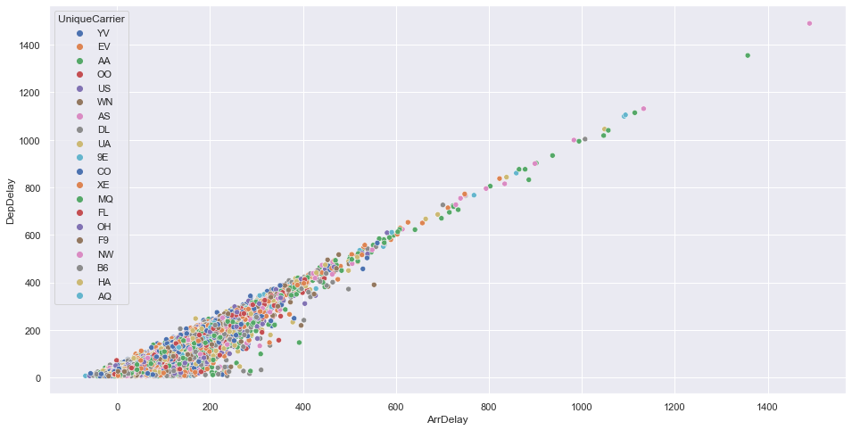

```python
sns.scatterplot(x='ArrDelay', y='DepDelay', data= subsample2, hue='UniqueCarrier', palette='deep')
plt.show()
```

The plot don't show any patron between delay and airlines

**Més de tres variables (ArrDelay, DepDelay, AirTime i UniqueCarrier).**

3 numerical variables and one categorical

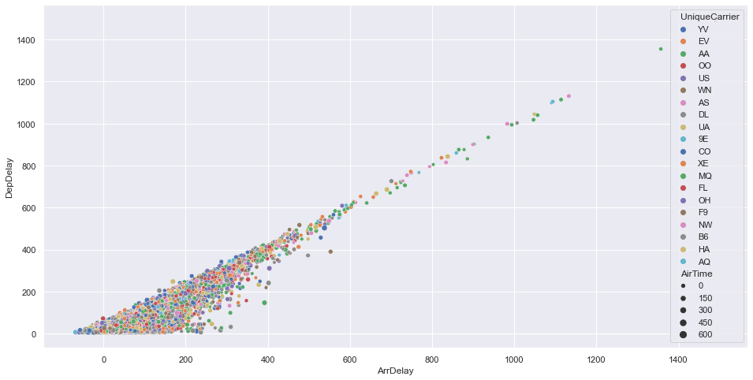

```python
sns.scatterplot(x='ArrDelay', y='DepDelay', size='AirTime', data= subsample2, hue='UniqueCarrier', palette='deep')
plt.show()
```

# Exercici 2

Exporta els gràfics com imatges o com html.

# Exercici 3

Integra les visualitzacions gràfiques, en la tasca 5, del Sprint 2.